# Machine Learning Model Predicting How People Exercise

My D. Coyne

June 21, 2015

# Executive Summary

A large dataset that contains self-monitoring data from people’s exercises, collected from self-movement devices is used to train a machine learning algorithm, specifically Random Forest. After training, the model is used to predict test data. The Random Forest algorithm perform extremely well–predict correctly 20 data points in the test dataset. The algorithm can be quite slow in running. The training dataset contains 19,622 data points, with 160 variables, which reduced to 53 variables after cleaning and preprocess.

# Abstract

Training a machine learning algorithm, specifically Random Forest, with self-monitoring data from people’s exercises. Then predict by assigning classifiers to test data. The paper also discuss the out of bag (OOB) error rates and identify other benefits of random forest offer, such as feature selection based on importance of data.

# Preprocess

## Library Require

The following packages are required to run the code.

1. install.packages (“caret”, dependencies=TRUE)
2. install.packages (“randomForest”)
3. install.packages (“e1071”, dependencies=TRUE)
4. install.packages(“pRF”, dependencies=TRUE)

```r
library(caret)

library(randomForest)

library(e1071)
```

## Read Training and Testing Data into the workspace

Read both training and testing datasets from files.

```r
options(stringsAsFactors = FALSE)

# Training filename and dataframe contains training data
trainingFn <- "../data/pml-training.csv"
trainingDf<- data.frame(read.csv(trainingFn,na.strings=c("NA",""),header=TRUE))

# Testing filenmae and dataframe contains testing data
testingFn <- "../data/pml-testing.csv"
testingDf<- data.frame(read.csv(testingFn,header=TRUE))
```

The input training dataset contains 19,622 rows with 160 variables.

```r
dim(trainingDf)
```

```
## [1] 19622   160
```

The test dataset contains 20 rows with 160 variables as well.

```r
dim(testingDf)
```

```
## [1]  20 160
```

## Cleaning Training and Testing data

Examine the data in both training and testing dataset, the observations are:

```r
# Consider only colum
trCleanDf.wk   <- trainingDf[, colMeans(is.na(trainingDf))   < 0.96]
```

2. Reviewing the column names of column 1 - 7 reveals that these variables do not contribute to the model. Hence, the variables are used in building the model will consist the 8th column and thereafter.

```r
colnames(trainingDf)[1:7]
```

```
## [1] "X"                    "user_name"            "raw_timestamp_part_1"
## [4] "raw_timestamp_part_2" "cvtd_timestamp"       "new_window"
## [7] "num_window"
```

```r
## trainingDf contains all columns with numeric and classes
trCleanDf.wk<- trCleanDf.wk[,8:dim(trCleanDf.wk)[2]]
```

3. Performing the same cleaning process with the testing dataset, i.e. remove columns that contains mostly NA’s and columns that do not contribute to building of the models.

```r
tsCleanDf.wk   <- testingDf[, colMeans(is.na(testingDf))   < 0.96]
## numeric data from column 8 to the next to last column

colnames(testingDf)[1:7]
```

```
## [1] "X"                    "user_name"            "raw_timestamp_part_1"
## [4] "raw_timestamp_part_2" "cvtd_timestamp"       "new_window"
## [7] "num_window"
```

```r
colnames(testingDf)[dim(testingDf)[2]]
```

```
## [1] "problem_id"
```

```r
tsCleanDf.wk <- tsCleanDf.wk[,8:dim(tsCleanDf.wk)[2]-1]
```

# Random Forest Model and Prediction

Building a model using Random Forest algorithm. Choosing a random number to for set.seed(); this is done so that the result will be same through different execution.

```r
set.seed(20150619)

classe.rf.model <- randomForest (as.factor(trCleanDf.wk$classe) ~ .
                                 , trCleanDf.wk
                                 , ntree=10
                                 , importance=TRUE
                                 , norm.votes=FALSE
                                )
```

Using the model to predict the test data

```r
pred <- predict (classe.rf.model, tsCleanDf.wk );

print(pred)
```

```
##  1  2  3  4  5  6  7  8  9 10 11 12 13 14 15 16 17 18 19 20
##  B  A  B  A  A  E  D  B  A  A  B  C  B  A  E  E  A  B  B  B
## Levels: A B C D E
```

For convenience of the submission process, the **write_prediction()** function that writes each prediction to a file.

```r
write_prediction = function(x){
  n = length(x)
  for(i in 1:n){
    filename = paste0("../output/problem_id_",i,".txt")
    write.table(x[i],file=filename,quote=FALSE,row.names=FALSE,col.names=FALSE)
  }
}

# write prediction to a file, ready for submission.
write_prediction(pred);
```

# Model Evaluation

In random forests, there is no need for cross-validation or a separate test set to get an unbiased estimate of the test set error; <sup>[2]</sup> instead **out of bag (OOB)** is used to get a running unbiased estimate of the classification error as trees are added to the forest. Random forest is a classification algorithm that combines both *boostrapping* and *random subspace method*. Each tree is constructed using a different bootstrap sample from the original data. About one-third of the cases are left out (*out of bag*) of the bootstrap sample and not used in the construction of the k-*th* tree. At the end of k-*th* run, out-of-bag estimate for the generalization error is the error rate of the out-of-bag classifier. Using OOB estimate removes the need for for set asside test set, or cross validation. The study of error estimates for bagged classifiers in Breiman[1996b]<sup>3</sup>, gives empirical evidence to show that the out-of-bag estimate is as accurate as using a test set of the same size as the training set. *Here, OOB will be used to address the out-of-sample errors classification.*

## Estimate of Error of the Classifier and Confusion Matrix

```r
classe.rf.model
```

```
##
## Call:
##  randomForest(formula = as.factor(trCleanDf.wk$classe) ~ ., data = trCleanDf.wk,      ntree = 10, importance = TRUE, norm.votes = FALSE)
##                Type of random forest: classification
##                      Number of trees: 10
## No. of variables tried at each split: 7
##
##         OOB estimate of  error rate: 3.21%
## Confusion matrix:
##      A    B    C    D    E class.error
## A 5429   56   20   14    7  0.01755338
## B   56 3582   62   20   33  0.04556355
## C   11   77 3245   44   18  0.04418262
## D   28   13   62 3053   21  0.03903053
## E    7   34   18   22 3482  0.02273365
```

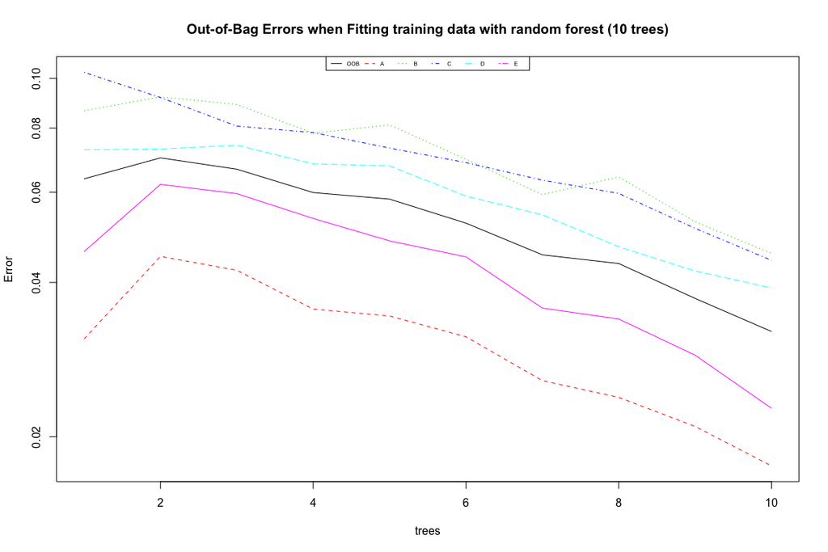

```r
plot(classe.rf.model
     , log="y"
     , main="Out-of-Bag Errors when Fitting training data with random forest (10 trees)")
legend("top", cex =0.5, legend=colnames(classe.rf.model$err.rate)
       , lty=c(1,2,3,4,5,6), col=c(1,2,3,4,5,6), horiz=T)
```

Let’s see if the OOB errors improved with more trees:

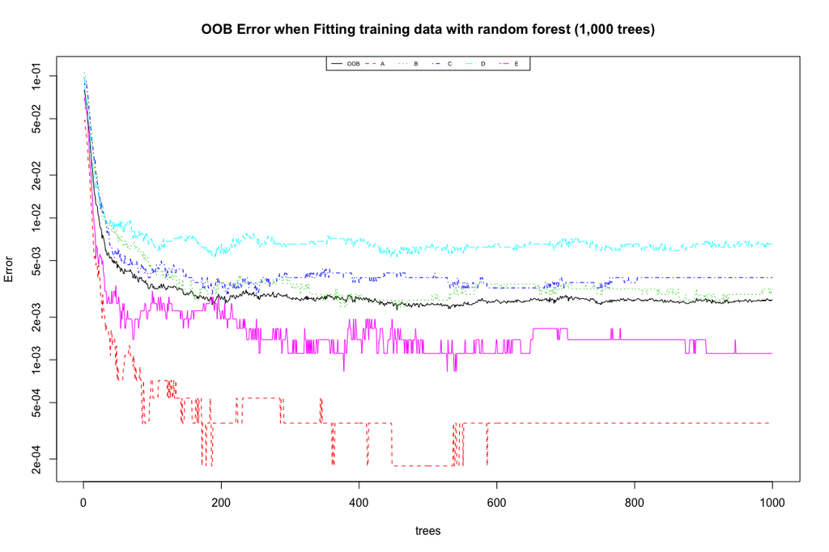

```r
classe.rf.model <- randomForest (as.factor(trCleanDf.wk$classe) ~ .
                                 , trCleanDf.wk
                                 , ntree=1000
                                 #, importance=TRUE
                                 , norm.votes=FALSE
                                )

plot(classe.rf.model
     ,log="y"
     ,main="OOB Error when Fitting training data with random forest (1,000 trees)")

legend("top", cex =0.5
       , legend=colnames(classe.rf.model$err.rate)
       , lty=c(1,2,3,4,5,6), col=c(1,2,3,4,5,6), horiz=T)
```

## Importance of Variables

The Random Forest algorithm produces two additional pieces of information:

1. a measure of the importance of the predictor variables and
2. a measure of the internal structure of the data (the proximity of different data points to one another).

The random forest algorithm estimates the importance of a variable by looking at how much prediction error increases when (OOB) data for that variable is permuted while all others are left unchanged.

There are two measures of importance: measure of how much **accuracy** that a predictor will influenec if it is removed from the prediction, and a measure of how much **impurity** that a node will incure if a variable is removed from the prediction. Impurity is meassured by Gini index. In the following section, the random classification will be calculated for 900 trees, and for each class A, B, C, D, E the mean decrease in accuracy measure of importance will be calculated and plot.

### Importance measurement by decreasing Accuracy

[output not shown]

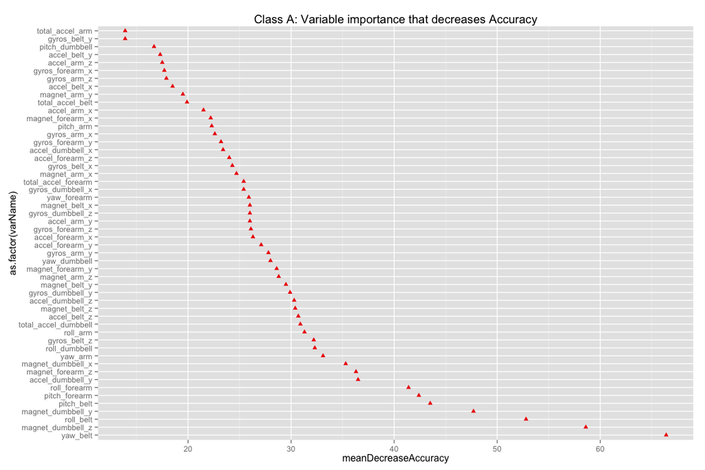

```r
classe.rf.model <- randomForest (as.factor(trCleanDf.wk$classe) ~ .
                                 , trCleanDf.wk
                                 , ntree= 900
                                 , importance=TRUE
                                 , proximity=TRUE
                                 , norm.votes=FALSE
                                )

## Class A
classA <- data.frame(importance(classe.rf.model, type=1, class="A"))
t1 <- data.frame(varName=rownames(classA), meanDecreaseAccuracy=round(classA[,"A"],1))
sortData <- transform(t1, varName=reorder(varName, -meanDecreaseAccuracy) )
pA<- ggplot(sortData, aes( as.factor(varName), meanDecreaseAccuracy))+
  ggtitle("Class A: Variable importance that decreases Accuracy")+
  geom_point(colour="red2", shape=17) +
  coord_flip()



classB <- data.frame(importance(classe.rf.model, type=1, class="B"))
t1 <- data.frame(varName=rownames(classB), meanDecreaseAccuracy=round(classB[,"B"],1))
sortData <- transform(t1, varName=reorder(varName, -meanDecreaseAccuracy) )
pB<- ggplot(sortData, aes( as.factor(varName), meanDecreaseAccuracy))+
  ggtitle("Class B: Variable importance that decreases Accuracy")+
  geom_point(colour="lawngreen", shape=17) +
  coord_flip()


classC <- data.frame(importance(classe.rf.model, type=1, class="C"))
t1 <- data.frame(varName=rownames(classC), meanDecreaseAccuracy=round(classC[,"C"],1))
sortData <- transform(t1, varName=reorder(varName, -meanDecreaseAccuracy) )
pC<- ggplot(sortData, aes( as.factor(varName), meanDecreaseAccuracy))+
  ggtitle("Class C: Variable importance that decreases Accuracy")+
  geom_point(colour="royalblue3", shape=17) +
  coord_flip()


classD <- data.frame(importance(classe.rf.model, type=1, class="D"))
t1 <- data.frame(varName=rownames(classD), meanDecreaseAccuracy=round(classD[,"D"],1))
sortData <- transform(t1, varName=reorder(varName, -meanDecreaseAccuracy) )
pD<- ggplot(sortData, aes( as.factor(varName), meanDecreaseAccuracy))+
  ggtitle("Class D: Variable importance that decreases Accuracy")+
  geom_point(colour="cyan2", shape=17) +
  coord_flip()

classE <- data.frame(importance(classe.rf.model, type=1, class="E"))
t1 <- data.frame(varName=rownames(classE), meanDecreaseAccuracy=round(classE[,"E"],1))
sortData <- transform(t1, varName=reorder(varName, -meanDecreaseAccuracy) )
pE<- ggplot(sortData, aes( as.factor(varName), meanDecreaseAccuracy))+
  ggtitle("Class E: Variable importance that decreases Accuracy")+
  geom_point(colour="hotpink2", shape=17) +
  coord_flip()
pA
```

```r
pB
```

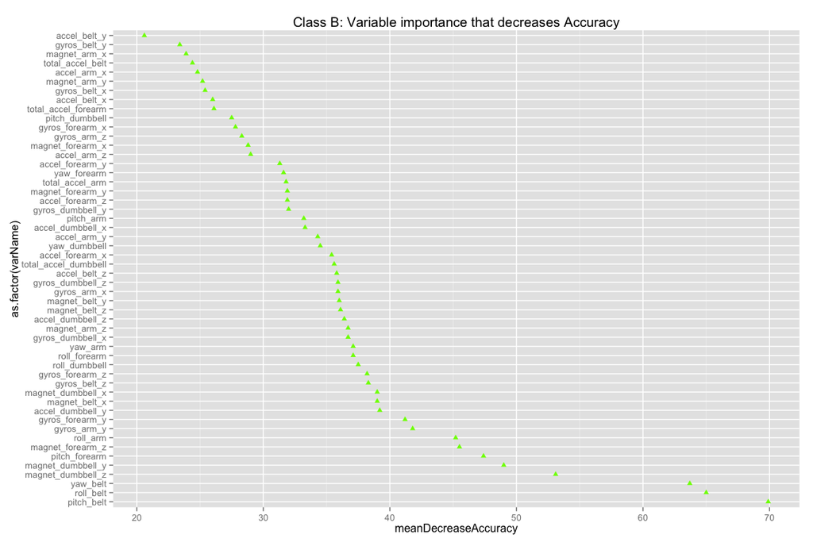

```r
pC
```

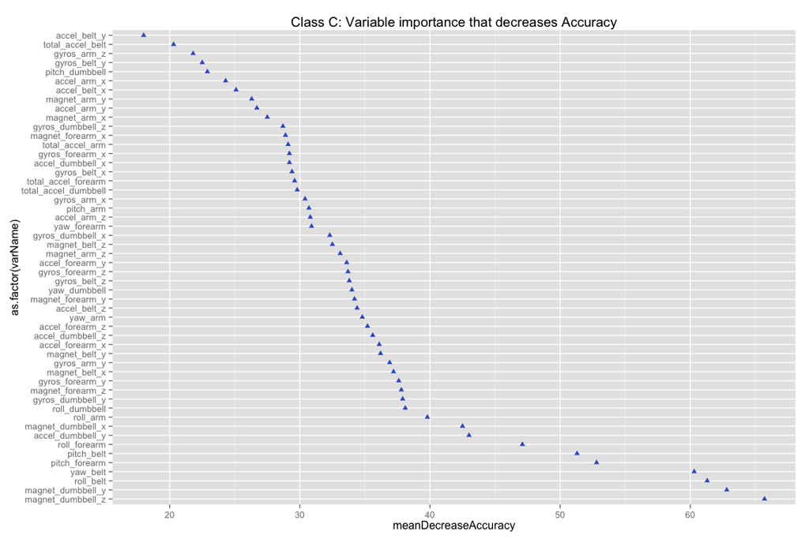

```r
pD
```

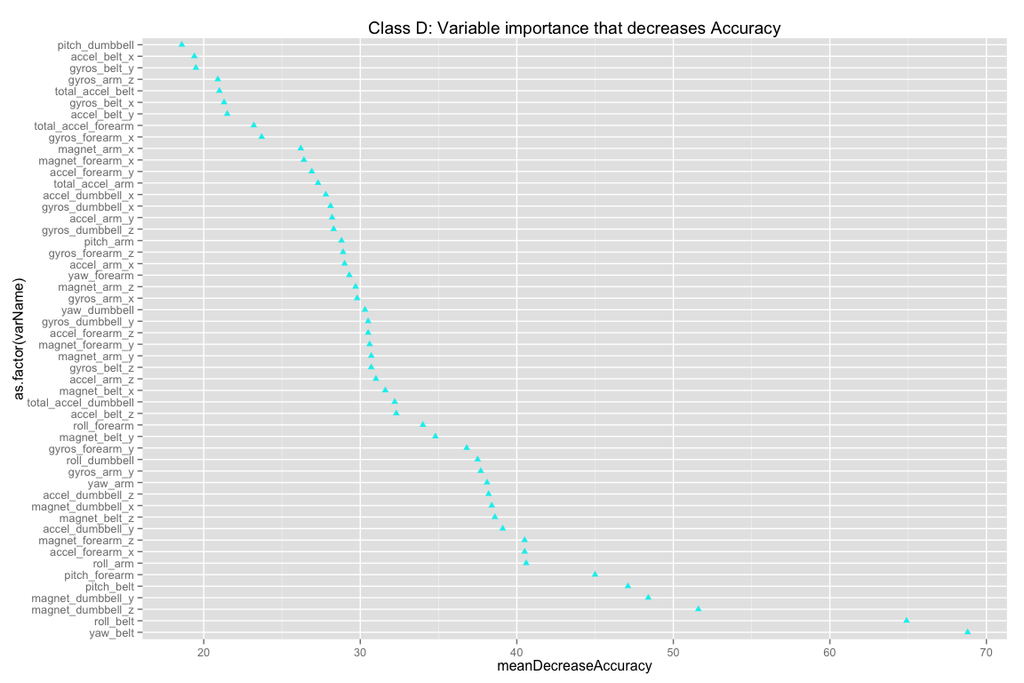

```r
pE
```

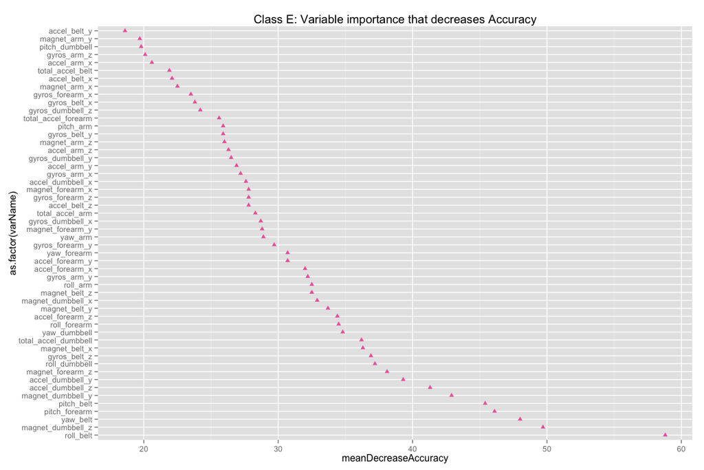

### Importance measurement by decreasing purity

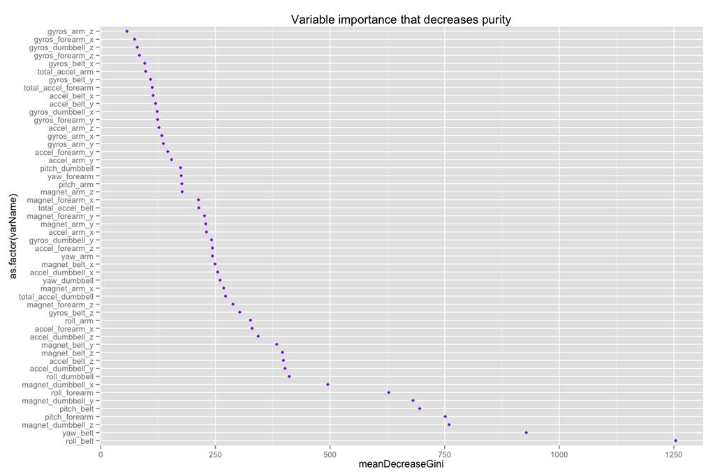

```r
varImp <- data.frame(importance(classe.rf.model, type=2))
t1 <- data.frame(varName=rownames(varImp), meanDecreaseGini=round(varImp[,"MeanDecreaseGini"],1))
sortData <- transform(t1, varName=reorder(varName, -meanDecreaseGini) )
pI<- ggplot(sortData, aes( as.factor(varName), meanDecreaseGini))+
  ggtitle("Variable importance that decreases purity")+
  geom_point(colour="purple2", shape=18) +
  coord_flip()

pI
```

# Conclusion

```r
pred <- predict (classe.rf.model, tsCleanDf.wk );

print(pred)
```

```
##  1  2  3  4  5  6  7  8  9 10 11 12 13 14 15 16 17 18 19 20
##  B  A  B  A  A  E  D  B  A  A  B  C  B  A  E  E  A  B  B  B
## Levels: A B C D E
```

Further study of the random forest, the importance of variables help in selecting important features. This also help in reducing the features, hence reducing the number of trees in shorting the execution time.

# References

1. Ugulino, W.; Cardador, D.; Vega, K.; Velloso, E.; Milidiu, R.; Fuks, H. **Wearable Computing: Accelerometers’ Data Classification of Body Postures and Movements.** Proceedings of 21st Brazilian Symposium on Artificial Intelligence. Advances in Artificial Intelligence - SBIA 2012. In: Lecture Notes in Computer Science. , pp. 52-61. Curitiba, PR: Springer Berlin / Heidelberg, 2012. ISBN 978-3-642-34458-9. DOI: 10.1007/978-3-642-34459-6_6.

Read more: http://groupware.les.inf.puc-rio.br/har#ixzz3ac1yTLFa

2. www.stat.berkeley.edu/~breiman/RandomForests/cc_home.htm
3. Breiman, L. [1996b] Out-of-bag estimation, ftp.stat.berkeley.edu/pub/users/breiman/OOBestimation.ps